# Using IPCC AR regions in R

M. Iturbide

2019-11-29

# 1 R packages

| Package | Citation |
| --- | --- |
| rgdal | Bivand et al., 2018 |
| sp | Pebesma and Bivand, 2005; Bivand et al., 2013 |
| RColorBrewer | Neuwirth, 2014 |
| loadeR | Iturbide et al., 2019 |
| visualizeR | Iturbide et al., 2019 |
| transformeR | Iturbide et al., 2019 |
| geoprocessoR | Iturbide et al., 2019 |

# 2 PART I: Using “rgdal” and “sp”

Package installation and loading:

```r
install.packages("rgdal")
install.packages("sp")
# We use RColorBrewer for creating color palettes:
install.packages("RColorBrewer")
```

```r
library(rgdal)
library(sp)
library(RColorBrewer)
```

## 2.1 Import the shapefile

The shapefile of the AR6 reference regions is available for download at the [IPCC-Atlas GitHub repository](https://github.com/SantanderMetGroup/IPCC-Atlas/tree/devel/reference_regions).

Function `readOGR` from package `rgdal` reads shapefiles into the R environment. The R object that is obtained is a `SpatialPolygonsDataFrame`, this is a `Spatial*` class object from package `sp`.

```r
AR6_WGI_referenceRegions <- readOGR("MyDir/AR6_WGI_referenceRegions.shp")
```

```r
class(AR6_WGI_referenceRegions)
```

```
## [1] "SpatialPolygonsDataFrame"
## attr(,"package")
## [1] "sp"
```

## 2.2 Load the R object

The *.rda object is also provided in the same link, thus, the Spatial object of the regions can be directly loaded into R as follows:

```r
load("MyDir/AR6_WGI_referenceRegions.rda", verbose = TRUE)
AR6_WGI_referenceRegions <- as(AR6_WGI_referenceRegions, "SpatialPolygons")
```

```
## Loading objects:
##   AR6_WGI_referenceRegions
```

We can simplify this object by converting it to a `SpatialPolygons` class object.

```r
AR6_WGI_referenceRegions <- as(AR6_WGI_referenceRegions, "SpatialPolygons")
```

Use function `plot` to visualize the regions:

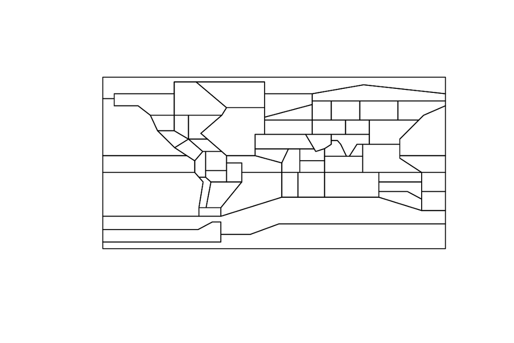

```r
plot(AR6_WGI_referenceRegions)
```

The R basic plotting functions allow adding layers to the plot. Here the region names and coastline are added. Shapefiles such as the Global coast lines or country boundaries are easily obtained from the Internet (e.g. https://www.naturalearthdata.com/downloads/).

```r
coastLines <- greadOGR("MyDir/world_coastlines.shp")
```

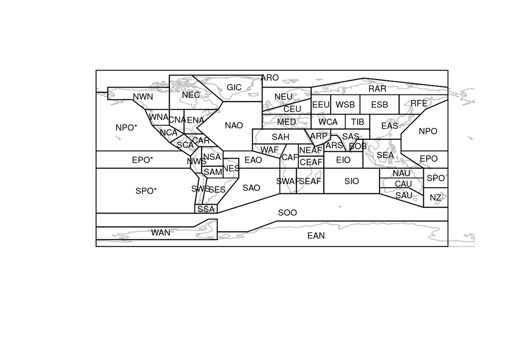

```r
plot(coastLines, col = "grey")
plot(AR6_WGI_referenceRegions, add = TRUE)
text(x = coordinates(AR6_WGI_referenceRegions)[,1],
    y = coordinates(AR6_WGI_referenceRegions)[,2],
    labels = names(AR6_WGI_referenceRegions), cex = 0.6)
```

## 2.3 Selecting specific regions

A singe region:

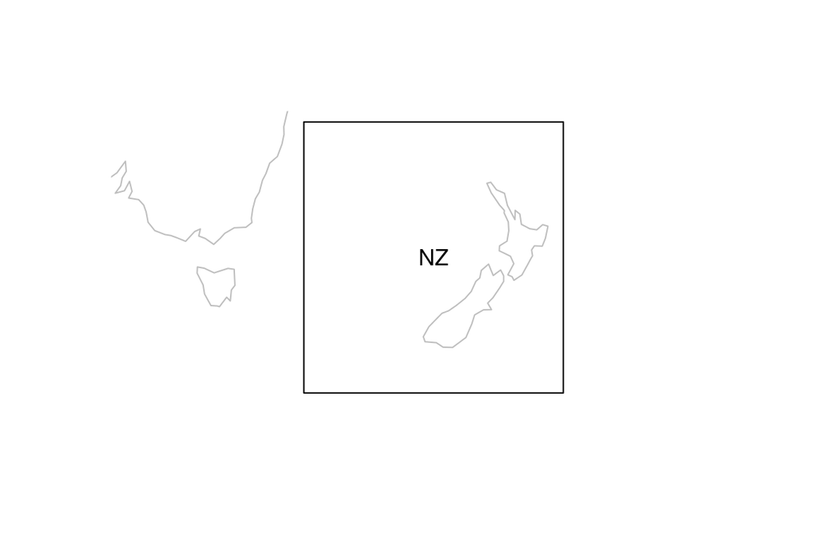

```r
newzealand <- AR6_WGI_referenceRegions["NZ"]
plot(newzealand)
plot(coastLines, col = "grey", add = TRUE)
text(x = coordinates(newzealand)[,1],
    y = coordinates(newzealand)[,2],
    labels = names(newzealand), cex = 1)
```

or several:

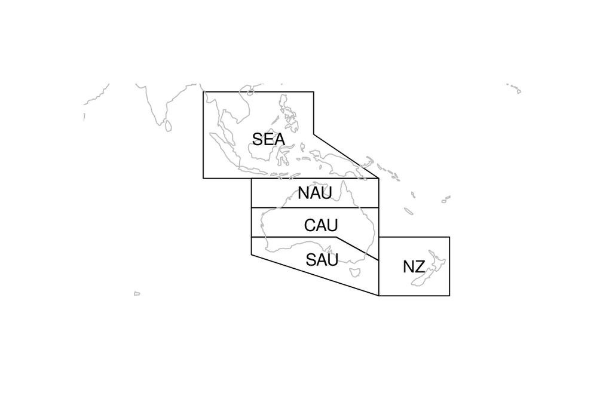

```r
australasia <- AR6_WGI_referenceRegions[c("NZ", "SEA", "NAU", "CAU", "SAU")]

plot(australasia)
plot(coastLines, col = "grey", add = TRUE)
text(x = coordinates(australasia)[,1],
    y = coordinates(australasia)[,2],
    labels = names(australasia), cex = 1)
```

## 2.4 Data loading

With the aim of illustrating how to work with the regions and gridded data, here we use as example the 1º degree IPCC Atlas reference land-sea mask, which is also available at GitHub in the form of a NetCDF file.

In this case, function `readGDAL` (package `rgdal`) is used:

```r
grid1 <- readGDAL("MyDir/land_sea_mask_1degree.nc4")
```

The class of object `grid1` is `SpatialGridDataFrame` from package `sp`:

```r
class(grid1)
```

```
## [1] "SpatialGridDataFrame"
## attr(,"package")
## [1] "sp"
```

## 2.5 Visualization

Function `spplot` is the map plotting tool of package `sp`:

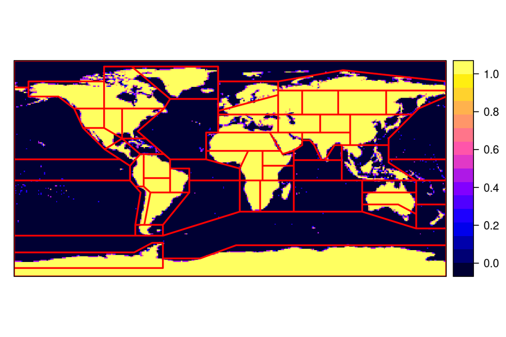

```r
spplot(grid1, sp.layout = list(AR6_WGI_referenceRegions, first = FALSE, col = "red", lwd = 2))
```

Argument `sp.layout` allows the visualization of as many Spatial* objects as we want. For example, region names can also be a Spatial object (object `regnameslayer` in the next example):

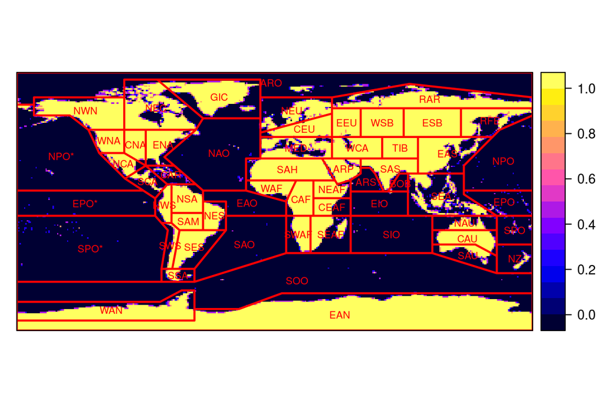

```r
regnameslayer <- list("sp.text", coordinates(AR6_WGI_referenceRegions), names(AR6_WGI_referenceRegions), col = "red", cex = 0.6)
spplot(grid1, sp.layout = list(list(AR6_WGI_referenceRegions, first = FALSE, col = "red", lwd = 2), regnameslayer))
```

Note that graphical parameters are easily set (e.g. `col`, `cex`, etc.)

## 2.6 Overlaping data and regions

The `over` function performs the instersection between different Spatial* object convinations, e.g. it implements the intersection of a `SpatialPixelsDataFrame` and a `SpatialPolygons object`. Therefore, next we convert `grid1` to a `SpatialPixelsDataFrame` object:

```r
grid1 <- as(grid1, "SpatialPixelsDataFrame")
```

The only requirement is equal projections. Use function `proj4string` to check and/or define, and `spTransform` to change the projection of a Spatial* object.

```r
proj4string((AR6_WGI_referenceRegions))
```

```
## [1] "+init=epsg:4326 +proj=longlat +datum=WGS84 +no_defs +ellps=WGS84 +towgs84=0,0,0"
```

```r
proj4string((grid1))
```

```
## [1] NA
```

In this example we do know that the projection is WGS84, same as `AR6_WGI_referenceRegions` (EPSG:4326), thus:

```r
proj4string(grid1) <- proj4string(AR6_WGI_referenceRegions)
```

Next `over` is applied for the regional subsets defined above:

```r
mask.nz <- grid1[!is.na(over(grid1, newzealand)),]
```

```r
mask.au <- grid1[!is.na(over(grid1, australasia)),]
```

We will keep the Austral-Asia subset from now on.

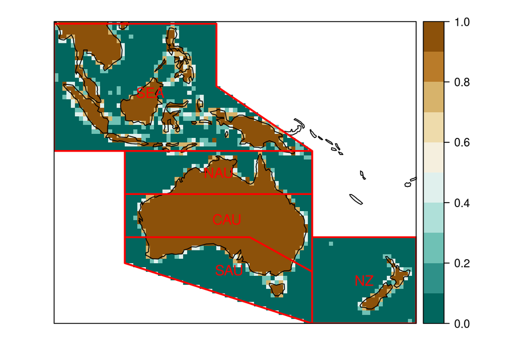

```r
colpal <- rev(brewer.pal(9, "BrBG"))
cols <- colorRampPalette(colpal)(10)

aulayer <- list(australasia, first = FALSE, col = "red", lwd = 2)
aunameslayer <- list("sp.text", coordinates(australasia), names(australasia), col = "red")

spplot(mask.au, sp.layout = list(list(coastLines), aulayer, aunameslayer),
       at = seq(0, 1, 0.1), col.regions = cols)
```

## 2.7 Data operations

For instance, the regional mean:

```r
mean(mask.au@data$band1)
```

```
## [1] 0.3872107
```

## 2.8 Data filtering

For instance, retain values above 0.5:

```r
mask.au <- mask.au[mask.au@data$band1 > 0.5,]
```

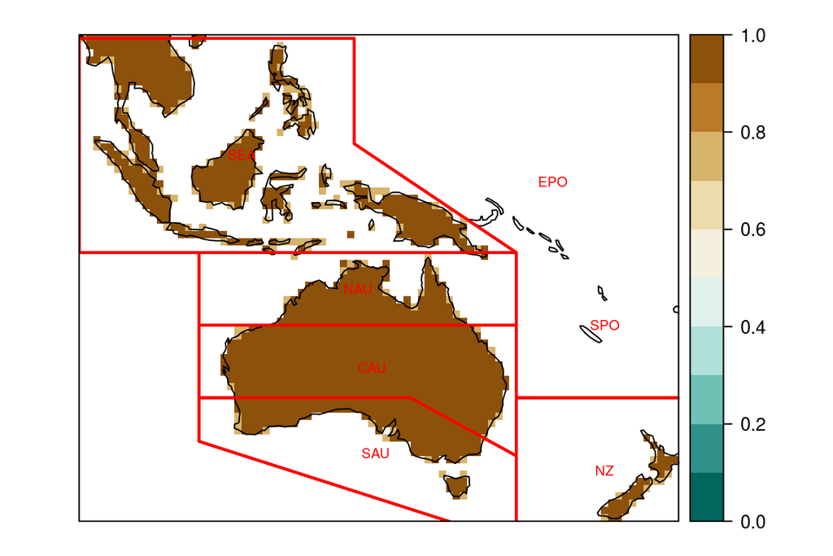

```r
spplot(mask.au, sp.layout = list(list(coastLines), aulayer, regnameslayer),
       at = seq(0, 1, 0.1), col.regions = cols)
```

The regional mean in this case is closer to 1 as it is calculated for the land area:

```r
mean(mask.au@data$band1)
```

```
## [1] 0.9735857
```

# 3 PART II: Using climate4R

Package installation and loading:

```r
library(devtools)
install_github(c("SantanderMetGroup/loadeR",
  "SantanderMetGroup/loadeR.java",
  "SantanderMetGroup/transformeR",
  "SantanderMetGroup/visualizeR",
  "SantanderMetGroup/geoprocessoR")
```

Note that there are more packages in climate4R. Here we use the ones required for this simple example. Go to the [climate4R GitHub repository](https://github.com/SantanderMetGroup/climate4R) for more information and worked examples.

```r
library(loadeR)
library(transformeR)
library(visualizeR)
library(geoprocessoR)
```

## 3.1 Load the AR6 regions

The Spatial* object of the regions is available in the `visualizeR` package, therefore, there is no need for previous download:

```r
data("AR6_WGI_referenceRegions")
```

## 3.2 Data loading

Previous to download we can perform an inventory of the dataset.

```r
di <- dataInventory("MyDir/land_sea_mask_1degree.nc4")
str(di)
```

```r
grid1 <- loadGridData("MyDir/land_sea_mask_1degree.nc4", var = "sftlf")
```

## 3.3 Visualization

`spatialPlot` is the map plotting function in climate4R (package `visualizeR`), which uses `spplot` internally, so it works in a very similar way and implements additional useful parameters (`backdrop.theme`, `set.min`, `set.max`, `lonCenter`, `color.theme`, `rev.colors`).

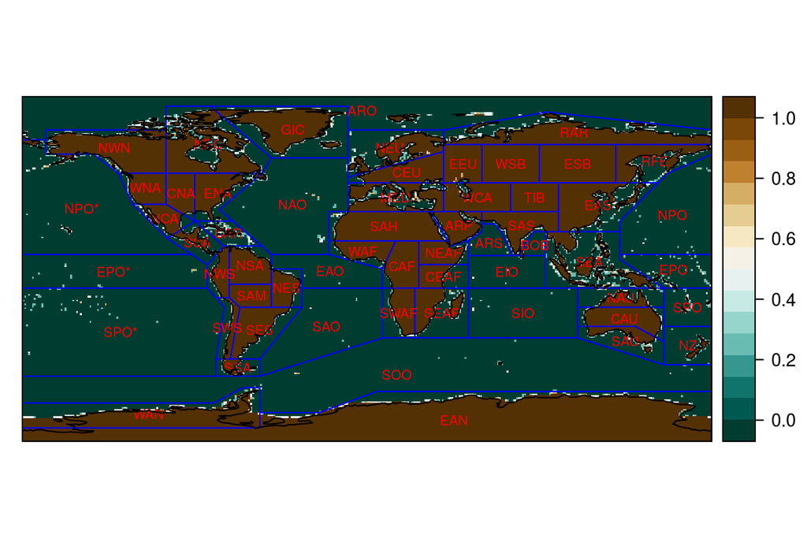

```r
spatialPlot(grid1, backdrop.theme = "coastline",
            color.theme = "BrBG",
            rev.colors = TRUE,
            sp.layout = list(list(AR6_WGI_referenceRegions, first = FALSE, col = "blue"), regnameslayer))
```

## 3.4 Overlaping data and regions

Function `overGrid` perfoms the operation of intersecting a climate4R grid and a Spatial object. The only requirement is equal projections. Use function `projectGrid` to define and/or change the projection of a grid. Use `proj4string` and `spTransform` for Spatial objects. In this example we do know that the projection is WGS84 (EPSG:4326), thus:

```r
grid1 <- projectGrid(grid1, original.CRS = proj4string(AR6_WGI_referenceRegions))
grid1.au <- overGrid(grid1, australasia)
```

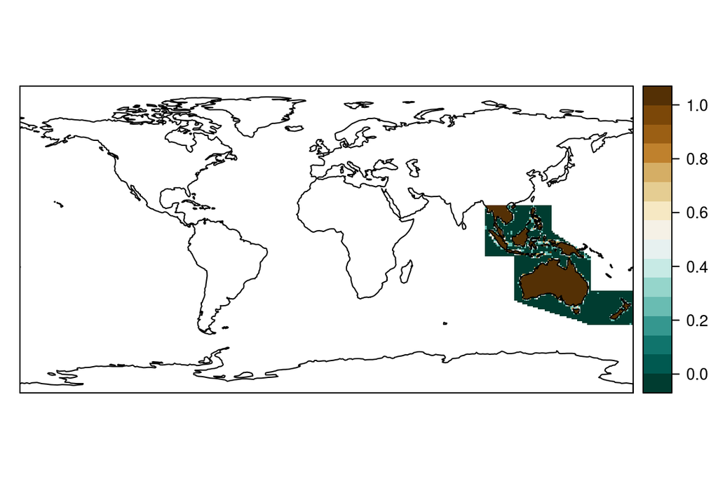

```r
spatialPlot(grid1.au,
            color.theme = "BrBG",
            rev.colors = TRUE,
            sp.layout = list(coastLines, first = FALSE, col = "black"))
```

If we set argument `subset` as `TRUE` we obtain…

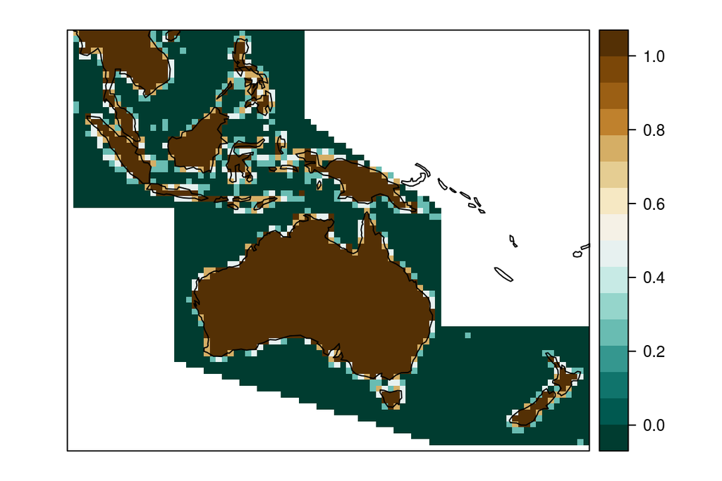

```r
grid1.au <- overGrid(grid1, australasia, subset = TRUE)

spatialPlot(grid1.au,
            color.theme = "BrBG",
            rev.colors = TRUE,
            sp.layout = list(coastLines, first = FALSE, col = "black"))
```

## 3.5 Data operations

For instance, the regional mean:

```r
mean(grid1.au$Data, na.rm = TRUE)
```

```
## [1] 0.3872107
```

It is convenient to use function `aggregateGrid` for data operations implying the aggregation of any of the dimensions, so that there is no need to extract the `$Data` and the grid object structure is mantained. Next we repeat the regional mean calculation but considering latitude weighting (`weight.by.lat = TRUE`):

```r
regmean <- aggregateGrid(grid1.au, aggr.lat = list(FUN = "mean", na.rm = TRUE),
                         weight.by.lat = TRUE,
                         aggr.lon = list(FUN = "mean", na.rm = TRUE))
regmean$Data
```

```
## [1] 0.3400356
## attr(,"dimensions")
## [1] "time"
```

Other usefule function is `gridArithmetics`, to perfom arithmetic operations with climate4R grids. For instance:

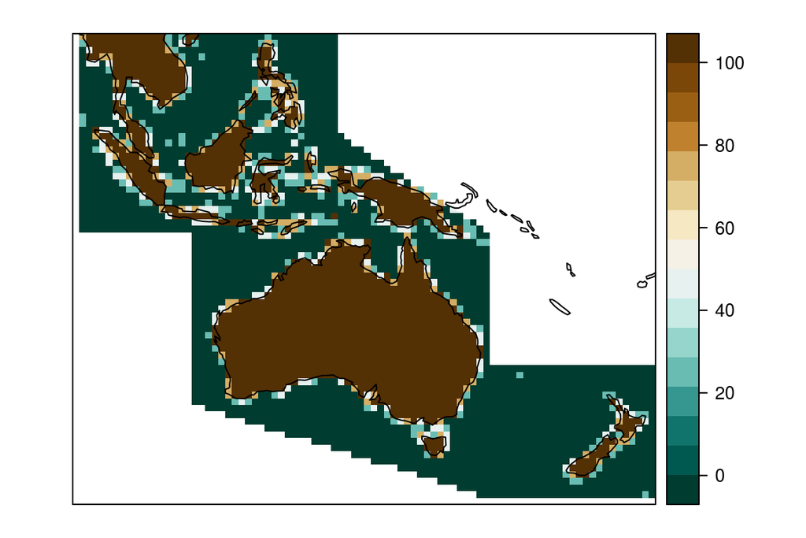

```r
grid100.au <- gridArithmetics(grid1.au, 100, operator = "*")
spatialPlot(grid100.au,
            color.theme = "BrBG",
            rev.colors = TRUE,
            sp.layout = list(coastLines, first = FALSE, col = "black"))
```